# Final Exam

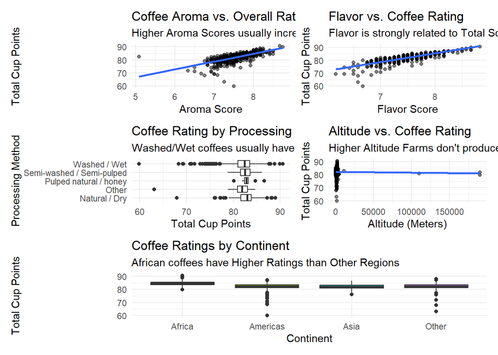

```r
## Dashboard

(p1 | p2) / (p3 | p4) / p5
```

Part 3: Predictive Modeling

```r
library(tidyverse)
library(caret)
library(rpart)
library(randomForest)
library(nnet)

# Split Data

set.seed(100)

train_index <- sample(1:nrow(coffee_clean),
                      size = 0.7 * nrow(coffee_clean))

coffee_train <- coffee_clean[train_index, ]
coffee_test <- coffee_clean[-train_index, ]

# 5-Fold Cross-Validation

ctrl <- trainControl(method = "cv",
                     number = 5)

## Model 1: Linear Regression (Subset)

mod1 <- train(total_cup_points ~ aroma + flavor + aftertaste,
              data = coffee_train,
              method = "lm",
              trControl = ctrl)

# Rationale:
# This is the simplest regression model and it only uses the strongest predictors.
```

```r
## Model 2: Linear Regression (All)

mod2 <- train(total_cup_points ~ aroma +
                flavor +
                aftertaste +
                altitude_mean_meters +
                species +
                processing_method +
                continent,
              data = coffee_train,
              method = "lm",
              trControl = ctrl)

# Rationale:
# This model uses both numeric and categorical predictors to see if more information improves prediction.
```

```r
## Model 3: Regression Tree

mod3 <- train(total_cup_points ~ aroma +
                flavor +
                aftertaste +
                altitude_mean_meters +
                processing_method,
              data = coffee_train,
              method = "rpart",
              trControl = ctrl)
# Rationale:
# A tree model shows you interactions and non linear relationships between predictors.
```

```r
## Model 4: Random Forest

mod4 <- train(total_cup_points ~ aroma +
                flavor +
                aftertaste +
                altitude_mean_meters +
                processing_method +
                continent,
              data = coffee_train,
              method = "rf",
              trControl = ctrl,
              importance = TRUE)

# Rationale:
# Random forests combine trees together and can improve prediction accuracy.
```

```r
## Model 5: Neural Network

mod5 <- train(total_cup_points ~ aroma +
                flavor +
                aftertaste +
                altitude_mean_meters,
              data = coffee_train,
              method = "nnet",
              linout = TRUE,
              trace = FALSE,
              trControl = ctrl)
# Rationale:
# Neural networks are flexible and can learn complex patterns in the data.
```

```r
## Comparing Performance

mod1$results
```

```
##   intercept     RMSE  Rsquared       MAE    RMSESD RsquaredSD      MAESD
## 1      TRUE 1.323303 0.7812503 0.7585014 0.3441938 0.05184144 0.06263693
```

```r
mod2$results
```

```
##   intercept     RMSE  Rsquared      MAE    RMSESD RsquaredSD      MAESD
## 1      TRUE 1.425531 0.7415616 0.781412 0.3676186 0.08443123 0.06417258
```

```r
mod3$results
```

```
##           cp     RMSE  Rsquared      MAE    RMSESD RsquaredSD      MAESD
## 1 0.09787794 1.913825 0.5450245 1.232109 0.1459610 0.04283270 0.16011280
## 2 0.15112278 2.016816 0.4932753 1.314532 0.1416931 0.08116684 0.09984301
## 3 0.42254324 2.401206 0.3900430 1.567710 0.2748998 0.02482022 0.26318766
```

```r
mod4$results
```

```
##   mtry     RMSE  Rsquared       MAE    RMSESD RsquaredSD      MAESD
## 1    2 1.407032 0.7787601 0.7737996 0.4503209 0.09016925 0.13217387
## 2    6 1.302145 0.7899576 0.7167425 0.2962571 0.08736495 0.07911341
## 3   11 1.343261 0.7769199 0.7438680 0.2934989 0.09387135 0.09429161
```

```r
mod5$results
```

```
##   size decay     RMSE     Rsquared       MAE    RMSESD   RsquaredSD      MAESD
## 1    1 0e+00 2.741553          NaN 1.8248528 0.4676825           NA 0.13334001
## 2    1 1e-04 2.741784 0.0001604278 1.8264731 0.4673080 1.168705e-05 0.13320901
## 3    1 1e-01 2.391489 0.1659730054 1.5876189 0.6751062 3.663460e-01 0.48033252
## 4    3 0e+00 2.741206 0.0009102078 1.8253253 0.4667488 1.410763e-03 0.13391381
## 5    3 1e-04 2.699722 0.0578922065 1.7817282 0.4899450 1.149107e-01 0.16361096
## 6    3 1e-01 1.468765 0.7384350981 0.7479459 0.3949991 1.195420e-01 0.08426485
## 7    5 0e+00 1.927856 0.7489015774 1.1795446 0.8210609 7.005521e-02 0.58090977
## 8    5 1e-04 1.881652 0.4813559717 1.1543267 0.7263521 4.288259e-01 0.56463562
## 9    5 1e-01 1.370282 0.7617217628 0.7427991 0.3364233 6.115007e-02 0.07281025
```

```r
## Lowest RMSE: 1.302145
## Best Model: Random Forest
```

Part 4: Model Comparison

```r
## Comparison Table

model_results <- tibble(

  Model = c("Linear Regression (Small)",
            "Linear Regression (All)",
            "Regression Tree",
            "Random Forest",
            "Neural Network"),
  RMSE = c(1.323303,
           1.425531,
           1.913825,
           1.302145,
           1.370282))

model_results
```

```
## # A tibble: 5 × 2
##   Model                      RMSE
##   <chr>                     <dbl>
## 1 Linear Regression (Small)  1.32
## 2 Linear Regression (All)    1.43
## 3 Regression Tree            1.91
## 4 Random Forest              1.30
## 5 Neural Network             1.37
```

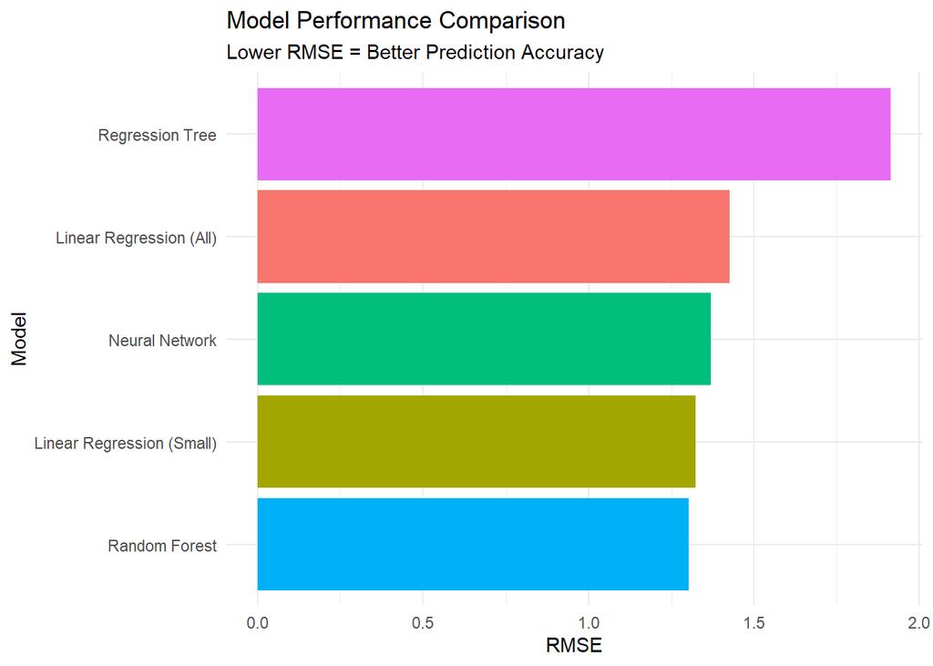

```r
## Visualization

ggplot(model_results,
       aes(x = reorder(Model, RMSE),
           y = RMSE,
           fill = Model)) +
  geom_col() +
  coord_flip() +
  labs(
    title = "Model Performance Comparison",
    subtitle = "Lower RMSE = Better Prediction Accuracy",
    x = "Model",
    y = "RMSE") +

  theme_minimal() +
  theme(legend.position = "none")
```

1.) Best Model: The Random Forest model performed best because it had the lowest RMSE of 1.30. This means it made the most accurate predictions. The smaller linear regression model also performed very well and it was simpler to understand. Even though the Random Forest performed best, it is harder to interpret than linear regression models.

2.) Alternative Metrics: MAE and R squared are other very useful metrics. MAE measures the average prediction error directly and R squared shows how much of the variation in coffee ratings is explained by the model.

3.) Implications of Predictions: The results show that coffee ratings can be predicted pretty well using sensory variables. Aroma and flavor were two of the strongest predictors and this is evidence that coffee quality scores are strongly connected to these sensory variables.